# Đề tài: Phân tích và đưa ra các giải pháp để cải thiện các chiến dịch marketing

Nhom09

2022-12-17

- Phần 1: Thông tin về project
  - 1.1 Bài toán
    - Có mối quan hệ giữa khu vực và sự chấp nhận của 1 chiến dịch (chiến dịch mới nhất) ? (chi-squared)
    - Có mối quan hệ giữa những người có con hoặc không có con và sự chấp nhận chiến dịch thành công nhất hay không ? (chi-squared)
    - Dự đoán tổng chi tiêu của khách hàng dựa trên thu nhập cá nhân, số lần mua hàng theo các phương thức, …
    - Dự đoán khả năng chấp nhận chiến dịch của khách hàng dựa vào lượt mua hàng, thu nhập, tình trạng hôn nhân, số con trong gia đình,…
  - 1.2 Tập dữ liệu, input, output của bài toán
    - Những biến trong tập dữ liệu:

```
##  [1] "ID"                  "Year_Birth"          "Education"
##  [4] "Marital_Status"      "Income"              "Kidhome"
##  [7] "Teenhome"            "Dt_Customer"         "Recency"
## [10] "MntWines"            "MntFruits"           "MntMeatProducts"
## [13] "MntFishProducts"     "MntSweetProducts"    "MntGoldProds"
## [16] "NumDealsPurchases"   "NumWebPurchases"     "NumCatalogPurchases"
## [19] "NumStorePurchases"   "NumWebVisitsMonth"   "AcceptedCmp3"
## [22] "AcceptedCmp4"        "AcceptedCmp5"        "AcceptedCmp1"
## [25] "AcceptedCmp2"        "Response"            "Complain"
## [28] "Country"
```

- Phần 2 - Giải pháp
  - 2.1. Phân tích sơ bộ:
    - Lọc sạch dữ liệu
    - Loại bỏ các cột không cần thiết và giá trị null
  - Trực quan hoá dữ liệu xây dựng mô hình hồi quy logistic

```
##
## Call:
## glm(formula = Response ~ Income + Education + Recency + MntWines +
##     MntFruits + MntMeatProducts + MntFishProducts + MntSweetProducts +
##     MntGoldProds + NumDealsPurchases + NumWebPurchases + NumCatalogPurchases +
##     NumStorePurchases + NumWebVisitsMonth, family = "binomial",
##     data = X_train)
##
## Deviance Residuals:
##     Min       1Q   Median       3Q      Max
## -2.2188  -0.4679  -0.2906  -0.1794   3.2780
##
## Coefficients:
##                       Estimate Std. Error z value Pr(>|z|)
## (Intercept)         -2.287e+00  8.661e-01  -2.640 0.008290 **
## Income              -1.941e-05  1.262e-05  -1.538 0.124139
## EducationBasic      -6.406e-01  9.027e-01  -0.710 0.477889
## EducationGraduation  3.265e-01  4.860e-01   0.672 0.501640
## EducationMaster      6.629e-01  5.278e-01   1.256 0.209184
## EducationPhD         1.015e+00  5.141e-01   1.975 0.048239 *
## Recency             -3.129e-02  4.313e-03  -7.254 4.04e-13 ***
## MntWines             1.220e-03  7.897e-04   1.545 0.122255
## MntFruits            7.671e-03  9.215e-03   0.832 0.405156
## MntMeatProducts      2.917e-03  1.853e-03   1.574 0.115503
## MntFishProducts     -1.356e-02  7.264e-03  -1.867 0.061925 .
## MntSweetProducts     1.473e-02  1.072e-02   1.374 0.169349
## MntGoldProds         4.046e-03  4.661e-03   0.868 0.385405
## NumDealsPurchases    1.052e-01  5.771e-02   1.824 0.068190 .
## NumWebPurchases      8.804e-02  6.506e-02   1.353 0.175964
## NumCatalogPurchases  2.249e-01  8.485e-02   2.650 0.008043 **
## NumStorePurchases   -2.634e-01  7.165e-02  -3.676 0.000237 ***
## NumWebVisitsMonth    2.111e-01  7.064e-02   2.988 0.002807 **
## ---
## Signif. codes:  0 '***' 0.001 '**' 0.01 '*' 0.05 '.' 0.1 ' ' 1
##
## (Dispersion parameter for binomial family taken to be 1)
##
##     Null deviance: 744.10  on 1093  degrees of freedom
## Residual deviance: 593.31  on 1076  degrees of freedom
##   (426 observations deleted due to missingness)
## AIC: 629.31
##
## Number of Fisher Scoring iterations: 6
```

- Trực quan hoá : Tỷ lệ chấp nhận các chiến dịch tiếp thị theo từng khu vực ?

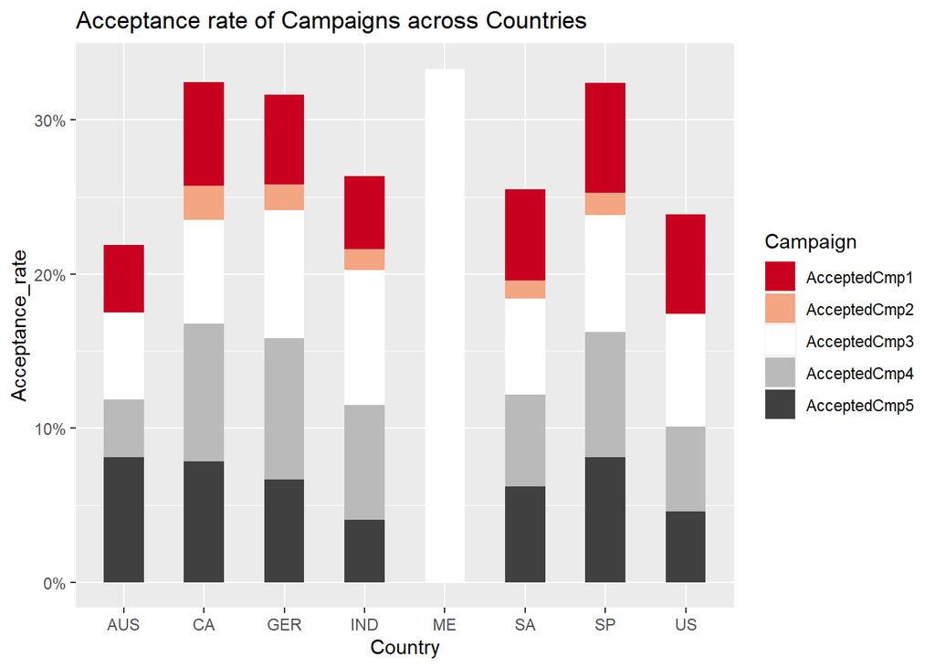

- 2. Các thuật toán/mô hình nhóm đã thử nghiệm:
  - Linear model
  - Logistic model
  - Chi-squared (kiếm định )

Phần 4: Kế hoạch tiếp theo

- Kế hoạch
  - Phát triển thêm Hồi quy Logistic, hồi quy tuyến tính
  - Phân tích sự khác nhau giữa những quốc gia phát triển và đang phát triển
  - Sử dụng mỗi mô hình cho những những kết quả dự đoán kết quả